# E02 - Intro to R Assignment (Analysis of Gene Expression @ UCT Prague)

2021-03-25

# 1 Introduction

This will be your first programming assignment. It covers the most important parts of `E02 - Intro to R`. **If you get really stuck, return what you have and describe your problems under problematic tasks.**

Please, return this assignment in this form:

- In the header, put your name and e-mail to `author` parameter (under `params`).
- Copy the finished assignment (this file) and its rendered HTML to directory named `E02-intro_to_R_assignment_<your_name>` and put this directory to ZIP archive named `E02-intro_to_R_assignment_<your_name>.zip`.
  - In rendered HTML there should be included all code chunks with full output (warnings, messages, etc.).
- Upload the ZIP file to the appropriate assignment in MS Teams.

Example of returned assignment ZIP:

```
E02-intro_to_R_assignment_Jiri_Novotny.zip
├── E02-intro_to_R_assignment_Jiri_Novotny
    ├── E02-intro_to_R_assignment.html
    ├── E02-intro_to_R_assignment.Rmd
```

Some tips:

- Use help pages, e.g. `?table` or `?dplyr::select`, or press F1 when cursor is at function location.
  - Alternatively, view help pages at [rdrr.io](https://rdrr.io/).
- Package vignettes are also very helpful.
- Google is your friend.

## 1.1 R programming tasks

> Write you code to chunk below each task.

> Required datasets should be already loaded in your R session (try e.g. `head(iris)`). If not, load them with `data("<name of dataset>")`, e.g. `data("iris")`.

# 2 Markdown exercise

> Just a quick exercise on Markdown. Use Markdown syntax to style the following sentences:

Make me bold.

Make me italic.

Make me strikethrough.

Place me to blockquote.

Replace me with link to your favourite web page.

Replace me with your favourite image.

Make the following unordered list: Item 1, Item 2 > Subitem 2-1 + Subitem 2-2, Item 3

Make ordered list from the list above.

# 3 apply-family functions exercise

> In the following tasks, stick to the apply-family (including `purrr` package) functions, please. You can also use functions operating on matrix rows or columns.

## 3.1

Calculate column means of `USArrests` dataset:

## 3.2

Do the same as above, but for `iris` dataset:

## 3.3

In `women` dataset, count how many values greater than 70 are in each column:

## 3.4

In `mtcars` dataset, count how many unique values are in each column:

## 3.5

Using `lapply()` or `purrr::map()`, return the first and last element of each element in `my_list`:

```r
my_list <- list(1:5, LETTERS[1:10], 1)
```

The output should be:

```
[[1]]
[1] 1 5

[[2]]
[1] "A" "J"

[[3]]
[1] 1 1
```

# 4 tidyverse exercise

> For these tasks, stick to the `tidyverse` packages (pipe operator, `dplyr`, `tidyr`, `stringr`, etc.), please. If possible, use the pipe operator to make connections between function calls (e.g. `select() %>% mutate() %>% ...`). Anyway don’t feel forced to prefer `tidyverse` over base R - it’s up to you what you use in your own future code, but for now, this exercise is for `tidyverse`.

Load `tidyverse` packages first:

```r
library(tidyverse)
```

## 4.1

Omit `wt` and `cyl` columns from `mtcars` dataset:

## 4.2

Same columns as above, but now select and rename them (in one step) to `weight` and `cylinders`:

## 4.3

Now instead of selecting only those two columns above, just rename them and return the full dataset:

## 4.4

Using one of the [select helpers](https://tidyselect.r-lib.org/reference/language.html), select columns ending with “ty” from `swiss` dataset:

## 4.5

Select columns `mpg`, `cyl` and `hp` from `mtcars` dataset, and arrange them by ascending `mpg` and descending `cyl`:

## 4.6

In `iris` dataset, filter rows with `Sepal.Length` greater than 7 and `Sepal.Width` less than 3:

## 4.7

In `iris` dataset, filter rows with `Petal.Length` greater than `Sepal.Width` and `Species` equal to “virginica”:

## 4.8

In `iris` dataset, filter rows with `Petal.Length` greater than minimum value of `Sepal.Length`:

## 4.9

In `iris` dataset, create a new column `Petal.Width.2` in which will be addition of `Petal.Width` and its mean:

## 4.10

In `iris` dataset, create a new column `Sepal.Length.Category`, which categorizes `Sepal.Length`:

- “small” if `Sepal.Length` is lower than 5
- "medium if `Sepal.Length` is between 5 and 6.5 (inclusive)
- “large” if `Sepal.Length` is greater than 6.5

Example output (not full results):

```
# A tibble: 3 x 6
  Sepal.Length Sepal.Width Petal.Length Petal.Width Species    Sepal.Length.Category
         <dbl>       <dbl>        <dbl>       <dbl> <fct>      <chr>
1          7           3.2          4.7         1.4 versicolor large
2          5.1         3.5          1.4         0.2 setosa     medium
3          4.9         3            1.4         0.2 setosa     small
```

## 4.11

In `iris` dataset, replace in `Species` column values `setosa`, `versicolor` and `virginica` with `set`, `versi` and `virgi`, respectively, and make `virgi` the reference (first) level for `Species`:

## 4.12

Group `mtcars` dataset by `am` and within each group, calculate mean value of `hp` and number of observations:

## 4.13

Do the same grouping as above and then filter rows with `gear` being 4 or 5, and arrange rows by `am` and `gear`:

## 4.14

Join two datasets `band_members` and `band_instruments` such that each `name` in `band_members` will get its instrument (`plays`):

Example output:

```
# A tibble: 2 x 3
  name  band    plays
  <chr> <chr>   <chr>
1 John  Beatles guitar
2 Paul  Beatles bass
```

## 4.15

Do the same as above, but now include also `name`s for which there isn’t any matching row in `band_instruments`:

Example output:

```
# A tibble: 3 x 3
  name  band    plays
  <chr> <chr>   <chr>
1 Mick  Stones  NA
2 John  Beatles guitar
3 Paul  Beatles bass
```

## 4.16

Using `tidyr::pivor_longer()`, convert the `billboard_sm` dataset below to long (tidy) format and save the result to `billboard_sm_long` variable:

```r
billboard_sm <- head(billboard, 2)
```

## 4.17

Now convert `billboard_sm_long` back to wide format:

## 4.18

Collapse by `,` to a single character unique values in `Species` column of `iris` dataset:

## 4.19

Using the same unique values as above, extract substrings between positions 2 and 5 (inclusive):

## 4.20

In `CO2` dataset below, filter rows with `Plant` starting with `Qn`:

```r
CO2 <- as.data.frame(CO2)
```

## 4.21

In the same dataset as above, extract the numbers from `Plant` column:

## 4.22

In `storms` dataset, filter rows with `name` containing “and” and discard duplicated rows by `name`:

## 4.23

In the same dataset as above, replace “tropical” in `status` by “tropic” (sorry for a nonsense example, but I couldn’t find a better one…):

## 4.24

Using `glue()`, make a correct sentence from the variables below, assign it to variable `sentence` and print it:

```r
library(glue)
word1 <- "like"
word2 <- "to"
word3 <- "I"
word4 <- "cook"
```

## 4.25

Split the `sentence` variable to word vector (i.e. `c("I", "like", ...)`:

## 4.26

Use `ggplot` to make scatterplot of `Sepal.Length` and `Petal.Length` with point color by `Species` in `iris` dataset. Save this plot to `p1` variable and print it:

## 4.27

Modify and save again the plot in `p1` variable as:

- Add title “Sepal Length vs. Petal Length”.
- Rename `x` and `y` axe titles to “Sepal Length” and “Petal Length”, respectively.

And print the plot again.

## 4.28

Create boxplots of `Petal.Length` splitted and colored by `Species` in `iris` dataset with black points shown in each group, save it to `p2` variable and print it. Points should be jittered or, generally, arranged in the way they won’t overlap each other.

`p2` example:

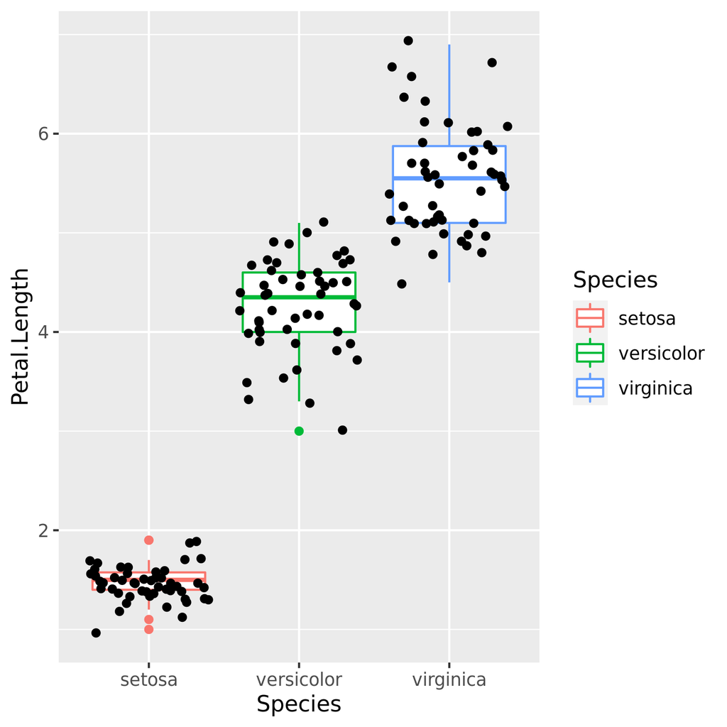

## 4.29

Combine `p1` and `p2` row-wise to a single figure (using the `patchwork` package):

```r
library(patchwork)
```

## 4.30

Do the same as above, but now combine the plots column-wise:

## 4.31

Use `ComplexHeatmap` to make a heatmap of `iris` dataset such that:

- In rows will be its four length variables (`Sepal.Length` etc.).
- Columns will be color-annotated by `Species`.
- Column title will be “iris”.
- Color legend for heatmap values will be named “Length”.

Tip: to draw color legends in one column, use `draw(p_heatmap, merge_legend = TRUE)`.

```r
library(ComplexHeatmap)
```

Heatmap example:

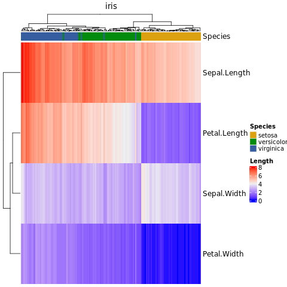

## 4.32

Do the same as above, but now transform iris lengths to z-score (scaling):